# Inverse Estimation in Linear Mixed-Effects Models

Brandon M. Greenwell

October 6, 2017

## Introduction

We consider the *statistical calibration* problem with *grouped data*; that is, data in which the observations are grouped into disjoint classes called clusters or groups. Common examples of grouped data include repeated measures data and longitudinal data. Groups tend to be homogeneous, therefore, observations belonging to the same group cannot be considered independent. (Although, observations between clusters usually are.) Thus, we need to account for within cluster dependence when modeling this type of data. To our knowledge, other than Oman (1998), very little has been done for calibration with grouped data. Oman considered a simpler model that only allowed for the intercept and slope to vary between groups, whereas we take a more general (and practical) approach that allows for an arbitrary random effects structure. Furthermore, while Oman considers only one type of calibration interval, we discuss four different calibration intervals that can be computed for grouped data, along with some adjustments to improve their accuracy. Moreover, the calibration interval considered by Oman was based on an approximate parametric bootstrap that did not account for the variance attributed by the random variable $Y_0$.

## Background

In this section, we provide a brief background of the statistical calibration problem in the context of ordinary regression with independent and normally distributed errors) and linear mixed-effects models (LMMs).

### Statistical calibration

A thoughrough overview of the statistical calibration is given in Osborne (1991) and Greenwell (2014)

### Prediction of future observations

In the literature for mixed models, prediction of future observations is often overshadowed by the prediction of random effects. Nonetheless, prediction of future observations in mixed models is an important topic—see Jiang (2007) for some motivating examples. For LMMs, there are two kinds of predictions we can make regarding a future observations: (1) predicting a new observation within an existing group, and (2) predicting a new observation in a new group. Since longitudinal studies often aim to make inference for the whole population under study—and not just the groups sampled—we will restrict our attention to case (2). In particular, for calibration, we will assume that a (single) new observation, denoted $Y_0$, is independent of the current observations and does not belong to an existing group.

## Statistical calibration in LMMs

### A parametric bootstrap algorithm

## Bladder volume by ultrasound

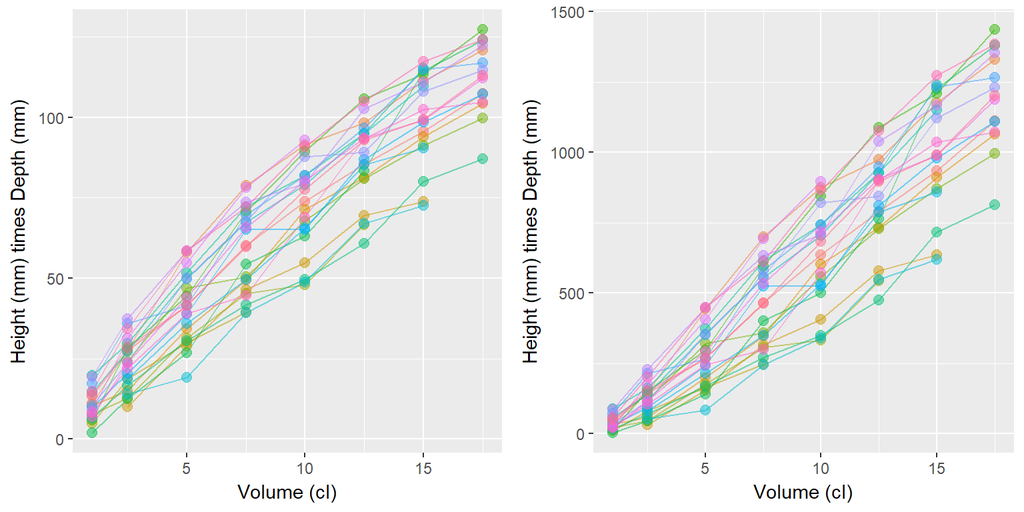

Spaghetti plots of the bladder volume by ultra sound data. *Left*: Original data. *Right*: Transfomed data.

|  | Value | Std.Error | DF | t-value | p-value |
| --- | --- | --- | --- | --- | --- |
| (Intercept) | -53.83164 | 11.603194 | 142 | -4.639381 | 7.9e-06 |
| volume | 69.09491 | 3.113645 | 142 | 22.191001 | 0.0e+00 |

# References

Greenwell, Brandon M. 2014. “Topics in Statistical Calibration.” PhD thesis, Air Force Institute of Technology.

Jiang, J. 2007. *Linear and Generalized Linear Mixed Models and Their Applications*. Springer Series in Statistics. Springer New York.

Oman, Samuel D. 1998. “Calibration with Random Slopes.” *Biometrika* 85 (2): 439–49.

Osborne, C. 1991. “Calibration: A Review.” *International Statistical Review* 59 (3): 309–36.